# Coding challanges for Session Five

Akos Mate

2020 July

We are using some new datasets for practice. If you are interested in various datasets for practice or personal pet projects, a good starting point is the [Tidy Tuesday](https://github.com/rfordatascience/tidytuesday) GitHub repo where they post a new dataset each week.

# Excercise 1 - Practicing `ggplot`

> Using the ‘squads’ data, create a scatterplot where the number of caps (international games played) is depicted along the X-axis, goals (international goals scored) is visualized at the Y-axis. Let’s add colors based on the footballer’s position.

More info on the dataset: https://github.com/rfordatascience/tidytuesday/tree/master/data/2019/2019-07-09

```r
squads <- readr::read_csv("https://raw.githubusercontent.com/rfordatascience/tidytuesday/master/data/2019/2019-07-09/squads.csv")
```

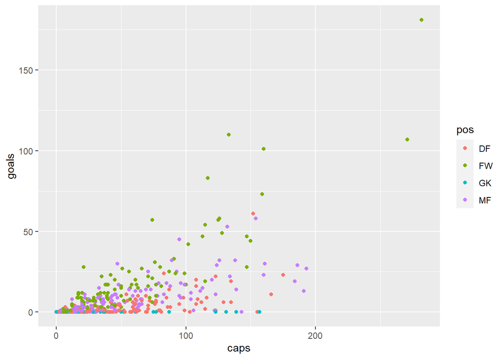

> Now, overlay multiple histograms on each other – use fill = variable to have a histogram of goals with players of different position depicted with different colors. You might want to trim (set the limits of) the x-axis at 75 goals, as very few players score more than that.

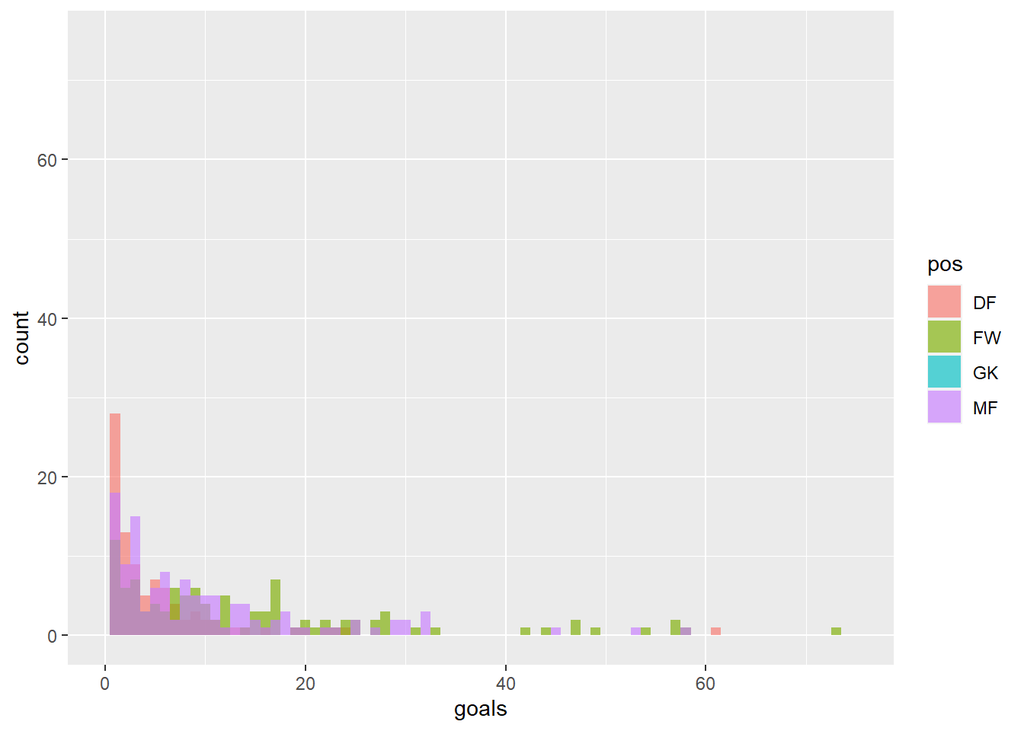

> Create a histogram of caps (international games played), fill the bars with grey color, and overlap it with a density plot, filled with the color ‘salmon’!

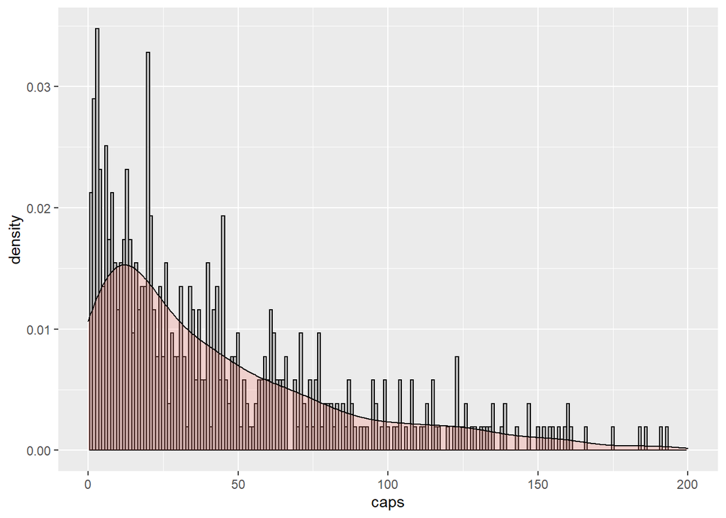

Now we use the other part of the World Cup data.

```r
wwc_outcomes <- readr::read_csv("https://raw.githubusercontent.com/rfordatascience/tidytuesday/master/data/2019/2019-07-09/wwc_outcomes.csv")
```

> Create a joyplot of *scores* using the wwc_outcomes data, using the result (i.e. whether the team won, lost or tied) as a grouping variable!

```r
library(ggridges)
```

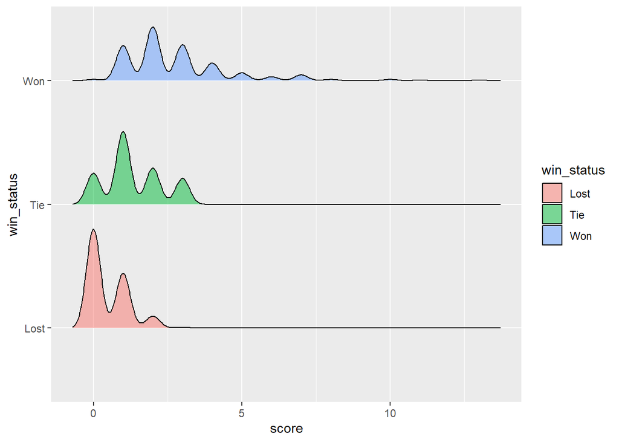